# Likelihood

```r
knitr::opts_chunk$set(echo = TRUE,
                      fig.align = 'center',
                      fig.width = 4,
                      fig.height = 4,
                      message = FALSE, warning = FALSE)
```

## Creating Bar Plots

The first section will briefly cover an alternative way to create bar charts in ggplot. Typically, `geom_bar` works by taking the frequency of observations in each column (see `?geom_bar` with the argument `stat = "count"`) and converting these to a value for the y axis

```r
library(ggplot2)
theme_set(theme_bw(base_size = 16))

set.seed(123)
df <- data.frame(fruit = sample(c("apple", "banana", "blueberry"), size = 10,
                                 replace = TRUE))
df
```

```
##        fruit
## 1  blueberry
## 2  blueberry
## 3  blueberry
## 4     banana
## 5  blueberry
## 6     banana
## 7     banana
## 8     banana
## 9  blueberry
## 10     apple
```

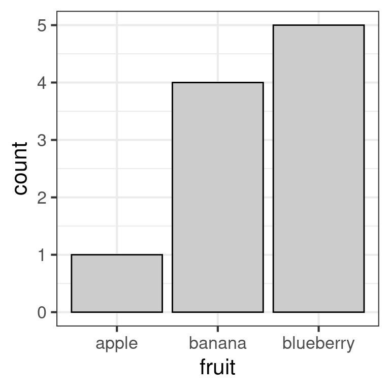

```r
ggplot(df, aes(x = fruit)) +
  geom_bar(color = "black",
           fill = "gray80")
```

Note here that the only aesthetic we use is `x`, designating fruit – the total are tabulated for us. If, however, the data was already tabulated with a value for the frequency:

```r
library(dplyr)

## Summarize the total number
df2 <- group_by(df, fruit) %>%
  summarize(N = n())

df2
```

```
## # A tibble: 3 × 2
##   fruit         N
##   <chr>     <int>
## 1 apple         1
## 2 banana        4
## 3 blueberry     5
```

We can modify the behavior of `geom_bar` by changing the `stat` argument to use this value instead:

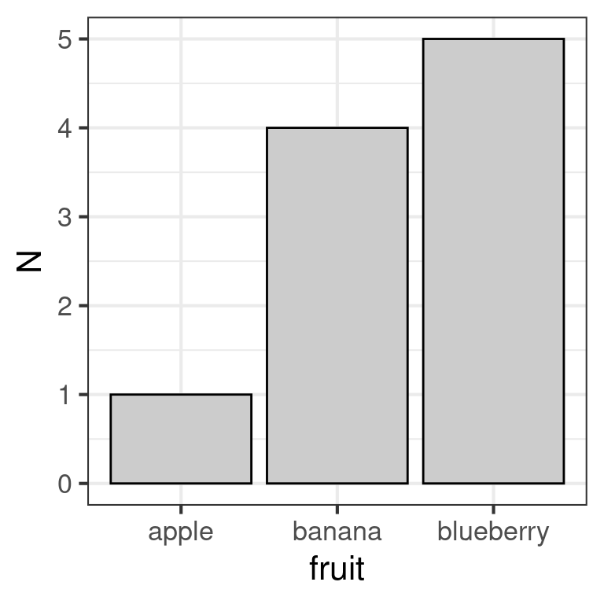

```r
ggplot(df2, aes(x = fruit, y = N)) +
  geom_bar(stat = "identity", # makes the labels match the value in Prob
           color = "black",
           fill = "gray80")
```

**Question 1** Using the method above, create a plot showing the PMF of $Y \sim Bin(n = 8, \pi = 0.6)$

## Vectorization

R is often saddled with a reputation for being slow, though this is largely a consequence of misunderstanding how R is intended to be used. Whereas loops are frequently used in other languages to perform sequences of operations of vectors, R often accomplishes the same thing much more quickly with a technique known as *vectorization*.

Vectorization, as the name implies, works by applying functions to vectors, which constitute the most basic unit in R (for example, in other languages $x = 3$ would be a *scalar* term, whereas in R it is a length one vector). Compare these below to see how it works

```r
x <- 1:10

## Always create a return vector of correct length for loops
y <- vector("numeric", length = length(x))

## Doing this with loops
for (i in seq_along(x)) {
  y[i] <- sqrt(x[i])
}

## Doing with vectorization
z <- sqrt(1:10)

identical(z, y)
```

```
## [1] TRUE
```

Not only is this typically faster, it makes reading the code much easier.

In fact, we saw an example of this in the last lab with the use of `dpois`

```r
dpois(x = 0:5, lambda = 2)
```

```
## [1] 0.135335 0.270671 0.270671 0.180447 0.090224 0.036089
```

Not all functions in R are vectorized, but many of them are. When in doubt, try it out.

**Question 2:** Use vectorization to create a plot of the *likelihood function* for $\pi$ when $Y$ is binomially distributed with $Y = 6$ and $n = 10$. A helpful function for this is `seq()`.

**Question 3:** What does the function `which.max()` do? Use this along with what you created in Question 2 to find the MLE for $\pi$. Does this match what you think it should be?